# Trending YouTube video's

*Sandy & co.*  
Marit Beerepoot  
Jessy Bosman  
Vincent Damen  
Laura Geerars  
Sander van Wickeren

# Introductie

*Onderzoeksvraag:*  
Wat zijn de factoren die trending video’s gemeen hebben?

*Deelvragen:*

1. Welke termen komen het meeste voor in trending video’s?
2. Is er een verschil tussen aantal likes, dislikes en ratio's ertussen?
3. Zijn er verschillen in titels tussen US, GB en CA bij trending video's?

# Literatuur

- YouTube video views al vaker gebruikt om populariteit te meten (Xie et al., 2011)
- Trending video's hebben een plotselinge peak in populariteit, bijvoorbeeld door externe events (Crane & Sonette, 2008)
- Tags maakt het vinden van video's makkelijker (Gill et al, 2007)
- Conformers voten positief op populaire items en negatief op onpopulaire items en dat mavericks dit andersom doen (Yin et al., 2012)

# Methodology:

# Data

csv's bevatten de volgende informatie:

- video ID
- datum waarop de video trending is
- titel
- channel
- tags
- likes
- dislikes
- aantal comments
- beschrijving en upload datum.

```python
trending.head()
```

|  | trending_date | title | channel_title | category_id | publish_time | tags | views | likes | dislikes | comment_count | thumbnail_link | comments_disabled | ratings_disabled | video_error_or_removed | description | category_name | like_view_ratio | dislike_view_ratio | like_dislike_ratio |
| --- | --- | --- | --- | --- | --- | --- | --- | --- | --- | --- | --- | --- | --- | --- | --- | --- | --- | --- | --- |
| 0 | 17.14.11 | WE WANT TO TALK ABOUT OUR MARRIAGE | CaseyNeistat | 22 | 2017-11-13T17:13:01.000Z | SHANtell martin | 748374 | 57527 | 2966 | 15954 | https://i.ytimg.com/vi/2kyS6SvSYSE/default.jpg | False | False | False | SHANTELL'S CHANNEL - https://www.youtube.com/s... | People & Blogs | 0.076869 | 0.003963 | 19.395482 |
| 1 | 17.14.11 | Me-O Cats Commercial | Nobrand | 22 | 2017-04-21T06:47:32.000Z | cute\|"cats"\|"thai"\|"eggs" | 98966 | 2486 | 184 | 532 | https://i.ytimg.com/vi/0mlNzVSJrT0/default.jpg | False | False | False | Kittens come out of the eggs in a Thai commerc... | People & Blogs | 0.025120 | 0.001859 | 13.510870 |
| 2 | 17.14.11 | AFFAIRS, EX BOYFRIENDS, $18MILLION NET WORTH -... | Shawn Johnson East | 22 | 2017-11-11T15:00:03.000Z | shawn johnson\|"andrew east"\|"shawn east"\|"shaw... | 321053 | 4451 | 1772 | 895 | https://i.ytimg.com/vi/STI2fI7sKMo/default.jpg | False | False | False | Subscribe for weekly videos ▶ http://bit.ly/sj... | People & Blogs | 0.013864 | 0.005519 | 2.511851 |
| 3 | 17.14.11 | BLIND(folded) CAKE DECORATING CONTEST (with Mo... | Grace Helbig | 22 | 2017-11-11T18:08:04.000Z | itsgrace\|"funny"\|"comedy"\|"vlog"\|"grace"\|"helb... | 197062 | 7250 | 217 | 456 | https://i.ytimg.com/vi/KODzih-pYlU/default.jpg | False | False | False | Molly is an god damn amazing human and she cha... | People & Blogs | 0.036790 | 0.001101 | 33.410138 |
| 4 | 17.14.11 | Wearing Online Dollar Store Makeup For A Week | Safiya Nygaard | 22 | 2017-11-11T01:19:33.000Z | wearing online dollar store makeup for a week\|... | 2744430 | 115426 | 1110 | 6541 | https://i.ytimg.com/vi/8mhTWqWlQzU/default.jpg | False | False | False | I found this online dollar store called ShopMi... | People & Blogs | 0.042058 | 0.000404 | 103.987387 |

# Evaluatie

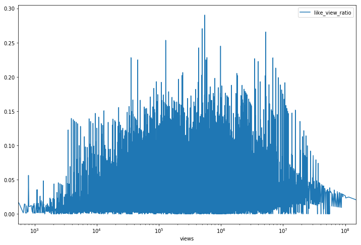

```python
# Voeg ratios toe
trending['like_view_ratio'] = trending.likes / trending.views
# Ratio likes ten opzichte van views.
trending.sort_values(by='views').plot(x='views', y="like_view_ratio", figsize=(12,8), logx=True)
```

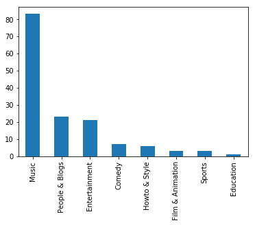

```python
# Welke categorieën zijn sterk vertegenwoordigd bij de hoge ratio?
trending[trending.like_view_ratio > 0.15].category_name.value_counts().plot(kind='bar')
```

```python
gen_word_cloud(contro, 1, False)
```

[output not shown]

```python
# Alle enkele woorden
titles = trending[trending.like_dislike_ratio > 1].title.values
gen_word_cloud(titles, 2, False)
```

[output not shown]

```python
# Alle beschrijvingen bekijken, enkele woorden.
description = trending.description.values
gen_word_cloud(description, 3, False)
```

[output not shown]

```python
# Biagrams van beschrijvingen
gen_word_cloud(description, 3, True)
```

[output not shown]

```python
US.sort_values("total",ascending=False)[["US","UK","CA"]][:30].plot(kind="bar",figsize=(20,20))
```

[output not shown]